Cartographie · Compositions · R

# DonutMap

Représenter les compositions sur une carte.

Cartes statiques et interactives, diagrammes en anneau et flux origine-destination.

`DonutMap` est un package R pour représenter des compositions locales sous forme de diagrammes en anneau placés sur une carte. Il fournit des fonctions pour créer des cartes statiques avec `ggplot2`, des cartes interactives avec `leaflet`, des polygones `sf` et des lignes de flux origine-destination.

Version CRAN : 0.1.0, publiée le 8 juin 2026.

[CRAN](https://cran.r-project.org/web/packages/DonutMap/index.html) [GitHub](https://github.com/AurelienNicosiaULaval/DonutMap) [Documentation](https://aureliennicosiaulaval.github.io/DonutMap/) [Vignette](https://aureliennicosiaulaval.github.io/DonutMap/articles/donut-maps.html)

## Aperçu visuel

L’image ci-dessous provient de la galerie d’exemples du package et montre une carte statique avec liens courbés et flèches.

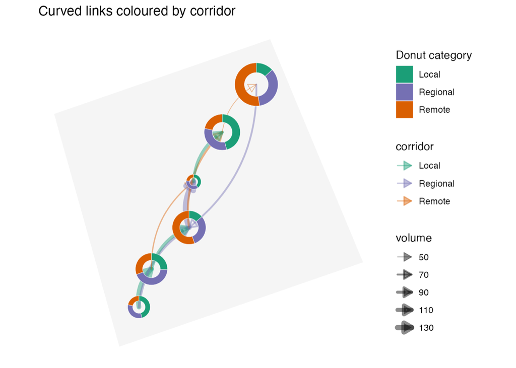

## Exemple d’utilisation

Le code suivant crée des diagrammes en anneau par site et ajoute des flux entre sites. Les données sont simulées pour illustrer la structure attendue par le package.

```r
# Load libraries
library(DonutMap)
library(ggplot2)

# Create example data
demo <- data.frame(
  place = rep(c("A", "B", "C"), each = 3),
  lon = rep(c(-71.35, -71.20, -71.05), each = 3),
  lat = rep(c(46.75, 46.82, 46.73), each = 3),
  category = rep(c("Walking", "Transit", "Car"), times = 3),
  value = c(10, 20, 5, 5, 15, 10, 12, 4, 9)
)

flows <- data.frame(
  from = c("A", "B"),
  to = c("B", "C"),
  trips = c(30, 10),
  flow_category = c("Transit", "Car")
)

mode_colours <- c(
  Walking = "#1b9e77",
  Transit = "#7570b3",
  Car = "#d95f02"
)

# Draw a static donut map
donut_map(
  demo,
  place,
  category,
  value,
  lon = lon,
  lat = lat,
  flows = flows,
  from = from,
  to = to,
  flow_value = trips,
  flow_group = flow_category,
  flow_colours = mode_colours,
  flow_curvature = 0.22,
  flow_arrow = TRUE,
  colours = mode_colours
)
```

## À quoi sert DonutMap ?

- comparer des compositions locales sur une carte ;
- visualiser des flux entre lieux avec des trajectoires droites ou courbées ;
- produire une carte statique `ggplot2` ou une carte interactive `leaflet` ;
- conserver une interface de données tidy compatible avec des flux de travail reproductibles.